# DATA-413/613 HW 7: Databases and SQL

Author

Te-Jou Hou(Carol)

# 1 Lahman Data

The Lahman database of baseball statistics is well known and documented here: http://seanlahman.com/.

There is a DuckDB version of the database in the `data` folder, along with a data dictionary.

Answer most questions using SQL code chunks. Use R chunks only for 1, 9, 10, and 11. Do not use the R Lahman package.

1. Create a connection to the Lahman data in the “data” folder.

```r
library(DBI)
library(duckdb)

con <- dbConnect(duckdb(dbdir = "../data/lahman23.duckdb", read_only = TRUE))
```

2. Use SQL to show the all the tables in this database.

```sql
SHOW TABLES;
```

Displaying records 1 - 10

| name |
| --- |
| AllstarFull |
| Appearances |
| AwardsManagers |
| AwardsPlayers |
| AwardsShareManagers |
| AwardsSharePlayers |
| Batting |
| BattingPost |
| CollegePlaying |
| Fielding |

- Show the columns in the Batting table and their column type.

```sql
DESCRIBE Batting;
```

Displaying records 1 - 10

| column_name | column_type | null | key | default | extra |
| --- | --- | --- | --- | --- | --- |
| playerID | VARCHAR | YES | NA | NA | NA |
| yearID | DOUBLE | YES | NA | NA | NA |
| stint | DOUBLE | YES | NA | NA | NA |
| teamID | VARCHAR | YES | NA | NA | NA |
| lgID | VARCHAR | YES | NA | NA | NA |
| G | DOUBLE | YES | NA | NA | NA |
| G_batting | DOUBLE | YES | NA | NA | NA |
| AB | DOUBLE | YES | NA | NA | NA |
| R | DOUBLE | YES | NA | NA | NA |
| H | DOUBLE | YES | NA | NA | NA |

- Show the columns in the Appearances table and their column type.

```sql
DESCRIBE Appearances;
```

Displaying records 1 - 10

| column_name | column_type | null | key | default | extra |
| --- | --- | --- | --- | --- | --- |
| yearID | DOUBLE | YES | NA | NA | NA |
| teamID | VARCHAR | YES | NA | NA | NA |
| lgID | VARCHAR | YES | NA | NA | NA |
| playerID | VARCHAR | YES | NA | NA | NA |
| G_all | DOUBLE | YES | NA | NA | NA |
| GS | DOUBLE | YES | NA | NA | NA |
| G_batting | DOUBLE | YES | NA | NA | NA |
| G_defense | DOUBLE | YES | NA | NA | NA |
| G_p | DOUBLE | YES | NA | NA | NA |
| G_c | DOUBLE | YES | NA | NA | NA |

1. Use the People table to create a table with playerID, first name, last name, debut and final game for players who played on or after the start of the 2021 season, on 1 April 2021, ordered by their debut with earliest at the top.
- What is the primary key for the table?

`playerID` is the primary key for the People table because it’s a unique code assigned to each player and it links the data in this file with records in the other files.

- Use SQL to show how many records were returned.

```sql
SELECT "playerID", "nameFirst", "nameLast", "debut", "finalGame"
FROM People
WHERE "finalGame" >= '2021-04-01'
ORDER BY "debut"
LIMIT 10;
```

Displaying records 1 - 10

| playerID | nameFirst | nameLast | debut | finalGame |
| --- | --- | --- | --- | --- |
| pujolal01 | Albert | Pujols | 2001-04-02 | 2022-10-04 |
| perezol01 | Oliver | Perez | 2002-06-16 | 2022-04-24 |
| cabremi01 | Miguel | Cabrera | 2003-06-20 | 2022-10-04 |
| leahyky01 | Kyle | Leahy | 2003-07-07 | 2023-07-20 |
| greinza01 | Zack | Greinke | 2004-05-22 | 2022-10-03 |
| molinya01 | Yadier | Molina | 2004-06-03 | 2022-10-05 |
| kazmisc01 | Scott | Kazmir | 2004-08-23 | 2021-09-30 |
| riverre01 | Rene | Rivera | 2004-09-22 | 2021-08-01 |
| canoro01 | Robinson | Cano | 2005-05-03 | 2022-07-27 |
| santaer01 | Ervin | Santana | 2005-05-17 | 2021-10-01 |

```sql
SELECT COUNT(*) AS total_records
FROM (
    SELECT "playerID", "nameFirst", "nameLast", "debut", "finalGame"
    FROM People
    WHERE "finalGame" >= '2021-04-01'
    ORDER BY "debut"
);
```

1 records

| total_records |
| --- |
| 2154 |

2. Use the Player and Appearances tables to create a table with the playerID, first name, last name, and total number of games for players who had appearances in the 2023 season. Sort in order of most games with appearances in the season and show the first 8 players.

```sql
SELECT
    Player."playerID",
    Player."nameFirst",
    Player."nameLast",
    Appearances."G_all"
FROM (
    SELECT
        "playerID",
        "nameFirst",
        "nameLast",
        "debut",
        "finalGame"
    FROM People
    WHERE "finalGame" >= '2021-04-01'
    ORDER BY "debut"
) AS Player
JOIN Appearances
    ON Player."playerID" = Appearances."playerID"
WHERE Appearances."yearID" = 2023
ORDER BY Appearances."G_all" DESC
LIMIT 8;
```

8 records

| playerID | nameFirst | nameLast | G_all |
| --- | --- | --- | --- |
| suareeu01 | Eugenio | Suarez | 162 |
| olsonma02 | Matt | Olson | 162 |
| sotoju01 | Juan | Soto | 162 |
| semiema01 | Marcus | Semien | 162 |
| freemfr01 | Freddie | Freeman | 161 |
| bregmal01 | Alex | Bregman | 161 |
| lowena01 | Nathaniel | Lowe | 161 |
| schwaky01 | Kyle | Schwarber | 160 |

4. Use the Batting table to create a table with the batting averages (defined as hits divided by at-bats, or `H/AB`), and the associated playerID’s, for the 2016 season in descending order.
- Be sure to account for players who may have more than one stint (record) as they played for more than one team in the season.
- Only include individuals with at least 50 at-bats.

```sql
SELECT
    "playerID",
    SUM("H") / SUM("AB") AS "battingAverages"
FROM Batting
WHERE "yearID" = 2016
GROUP BY "playerID"
HAVING SUM("AB") >= 50
ORDER BY "battingAverages" DESC;
```

Displaying records 1 - 10

| playerID | battingAverages |
| --- | --- |
| lemahdj01 | 0.3478261 |
| murphda08 | 0.3465160 |
| turnetr01 | 0.3420195 |
| altuvjo01 | 0.3375000 |
| rivertj01 | 0.3333333 |
| vottojo01 | 0.3255396 |
| perazjo01 | 0.3236515 |
| blackch02 | 0.3235294 |
| segurje01 | 0.3186813 |
| bettsmo01 | 0.3184524 |

5. Use `People` and `Batting` to calculate the batting average (`H` / `AB`) for Babe Ruth in 1931?
- Use SQL to get Ruth’s playerID and then use that ID to get his total Hits (`H`) and total At Bats (`AB`) in 1931.
- He only played for one team.
- This should only be one SQL call (and you won’t get credit if you manually type Ruth’s playerID).
- Round it to three digits as part of the SELECT.
- What is the primary key and the foreign key used in your query?

```sql
SELECT
    People."playerID",
    People."nameFirst",
    People."nameLast",
    Batting."yearID",
    ROUND(Batting."H" / Batting."AB", 3) AS "battingAverage"
FROM
    People
JOIN
    Batting
    ON People."playerID" = Batting."playerID"
WHERE
    People."nameFirst" = 'Babe'
    AND People."nameLast" = 'Ruth'
    AND Batting."yearID" = 1931;
```

1 records

| playerID | nameFirst | nameLast | yearID | battingAverage |
| --- | --- | --- | --- | --- |
| ruthba01 | Babe | Ruth | 1931 | 0.373 |

In the `People` table, the primary key is playerID, while the primary key in the `Batting` table is a combination of playerID and yearID. The playerID in the `Batting` table is a foreign key used to reference the corresponding data in the `People` table.

6. Use `Batting` to create a result set with the year (starting with 1871) and the average batting average for ALL players across all stints that year and place in descending order by the batting average.
- A year’s batting average is the total number of hits (`H`) for all players divided by the total number of official at bats (`AB`) for all players.

```sql
SELECT
    "yearID",
    SUM("H") / SUM("AB") AS "averageBatting"
FROM
    Batting
WHERE
    "yearID" >= 1871
GROUP BY
    "yearID"
ORDER BY
    "averageBatting" DESC;
```

Displaying records 1 - 10

| yearID | averageBatting |
| --- | --- |
| 1894 | 0.3093075 |
| 1895 | 0.2963126 |
| 1930 | 0.2956764 |
| 1925 | 0.2916237 |
| 1897 | 0.2915836 |
| 1921 | 0.2909642 |
| 1873 | 0.2904652 |
| 1896 | 0.2904259 |
| 1929 | 0.2891914 |
| 1922 | 0.2883908 |

7. Use `Batting` and `Pitching` to create a result set with the year, the overall batting average for the year, and the overall average of Earned Runs per batter for the year and the Ratio of batting average divided by Earned Runs per Batter for each year.
- Calculate average of Earned Runs per batter for the year as Earned Runs (`ER`)/batters faced by pitcher (`BFP`) from the `Pitching` table.
- Sort by Ratio with the lowest values at the top.
- You should have one row for each year that summarizes the results across all batters/pitchers.

```sql
SELECT
    Batting."yearID",
    SUM(Batting."H") / SUM(Batting."AB") AS "BA",
    SUM(Pitching."ER") / SUM(Pitching."BFP") AS "ERB",
    "BA" / "ERB" AS "ratio"
FROM
    Batting
JOIN
    Pitching
    ON Batting."yearID" = Pitching."yearID"
GROUP BY
    Batting."yearID"
ORDER BY
    ratio;
```

Displaying records 1 - 10

| yearID | BA | ERB | ratio |
| --- | --- | --- | --- |
| 2020 | 0.2446044 | 0.1150874 | 2.125381 |
| 2019 | 0.2522577 | 0.1165470 | 2.164429 |
| 2021 | 0.2438172 | 0.1110946 | 2.194681 |
| 2023 | 0.2483852 | 0.1126429 | 2.205068 |
| 2000 | 0.2704645 | 0.1204556 | 2.245346 |
| 2017 | 0.2549723 | 0.1130468 | 2.255459 |
| 1999 | 0.2711967 | 0.1191774 | 2.275571 |
| 2018 | 0.2479448 | 0.1083024 | 2.289375 |
| 1996 | 0.2698962 | 0.1172283 | 2.302314 |
| 2001 | 0.2639592 | 0.1136349 | 2.322871 |

8. Write the result of the previous query to the output folder as “year_ba_erb.csv”.

```sql
COPY
(
    SELECT
        Batting."yearID",
        SUM(Batting."H") / SUM(Batting."AB") AS "BA",
        SUM(Pitching."ER") / SUM(Pitching."BFP") AS "ERB",
        "BA" / "ERB" AS "ratio"
    FROM
        Batting
    JOIN
        Pitching
        ON Batting."yearID" = Pitching."yearID"
    GROUP BY
        Batting."yearID"
    ORDER BY
        ratio
)
TO '../output/year_ba_erb.csv' (HEADER, DELIMITER ',');
```

9. Repeat the query from 7 but do so in a way that returns an R data.frame. Save the data frame.

```r
query <- "
    SELECT
        Batting.\"yearID\",
        SUM(Batting.\"H\") / SUM(Batting.\"AB\") AS \"BA\",
        SUM(Pitching.\"ER\") / SUM(Pitching.\"BFP\") AS \"ERB\",
        \"BA\" / \"ERB\" AS \"ratio\"
    FROM
        Batting
    JOIN
        Pitching
        ON Batting.\"yearID\" = Pitching.\"yearID\"
    GROUP BY
        Batting.\"yearID\"
    ORDER BY
        ratio;
"

my_df <- DBI::dbGetQuery(conn = con,
                           statement = query)
```

10. Plot the relationship between ERB and BA with a linear smoother and facet by decade so it looks like the plot below.
- What do you notice about the plots? Comment on the slope of the smother and the ranges of the axes.

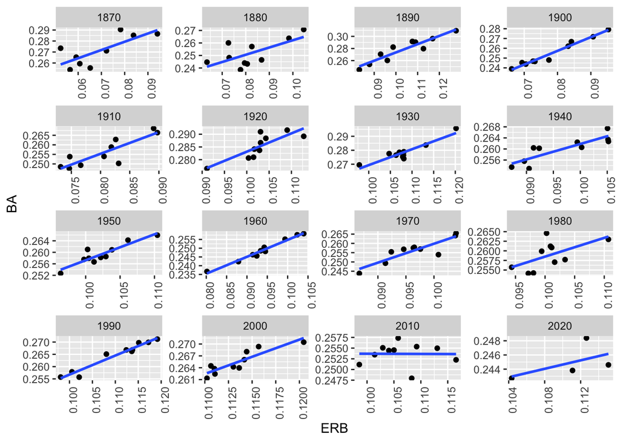

```r
library(tidyverse)

my_df <- my_df %>%
  mutate(decade = floor(yearID / 10) * 10)

ggplot(my_df, aes(x = ERB, y = BA)) +
  geom_point() +
  geom_smooth(method = "lm", se = FALSE) +
  facet_wrap(~ decade, ncol = 4, scales = "free") +
  labs(x = "ERB", y = "BA")+
  theme(axis.text.x = element_text(angle = 90, hjust = 1))
```

**Slope of the smoother**: Overall, the slopes are mostly positive (indicating a positive correlation), except for the 2010s, where it is almost flat.

11. Close your connection.

```r
DBI::dbDisconnect(con, shutdown = TRUE)
```